# SCTK Cell QC Report

December 17, 2021

# 1 Introduction

Comprehensive quality control (QC) of single-cell RNA-seq data was performed with the [**singleCellTK**](https://github.com/compbiomed/singleCellTK/tree/devel) package. This report contains information about each QC tool and visualization of the QC metrics for each sample. For more information on running this pipeline and performing quality control, see the [**documentation**](https://www.camplab.net/sctk/v2.2.1/articles/articles/cmd_qc.html). If you use the singleCellTK package for quality control, please include a [**reference**](https://www.biorxiv.org/content/10.1101/329755v1.article-info) in your publication.

# 2 Summary Statistics

|  | Total |
| --- | --- |
| Number of Cells | 2700 |
| Mean counts | 2366.9 |
| Median counts | 2197 |
| Mean features detected | 846.99 |
| Median features detected | 817 |
| scDblFinder - Number of doublets | 87 |
| scDblFinder - Percentage of doublets | 3.22 |
| DecontX - Mean contamination | 0.0808 |
| DecontX - Median contamination | 0.055 |

The summary statistics table summarizes QC metrics of the cell matrix. This table summarizes the mean and median of UMI counts and median of genes detected per cell, as well as the number and percentages of doublets and estimated ambient RNA scores per dataset.

# 3 General quality control metrics

SingleCellTK utilizes the [scater](https://bioconductor.org/packages/release/bioc/html/scater.html) package to compute cell-level QC metrics. The wrapper function `runPerCellQC` can be used to separately compute QC metrics on its own. The wrapper function `plotRunPerCellQCResults` can be used to plot the general QC outputs. The QC outputs are `sum`, `detected`, and `percent_top_X`. `sum` contains the total number of counts for each cell. `detected` contains the total number of features for each cell. `percent_top_X` contains the percentage of the total counts that is made up by the expression of the top X genes for each cell. The `subsets_` columns contain information for the specific gene list that was used. For instance, if a gene list containing mitochondrial genes named `mito` was used, `subsets_mito_sum` would contains the total number of mitochondrial counts for each cell.

## 3.1 Total Counts

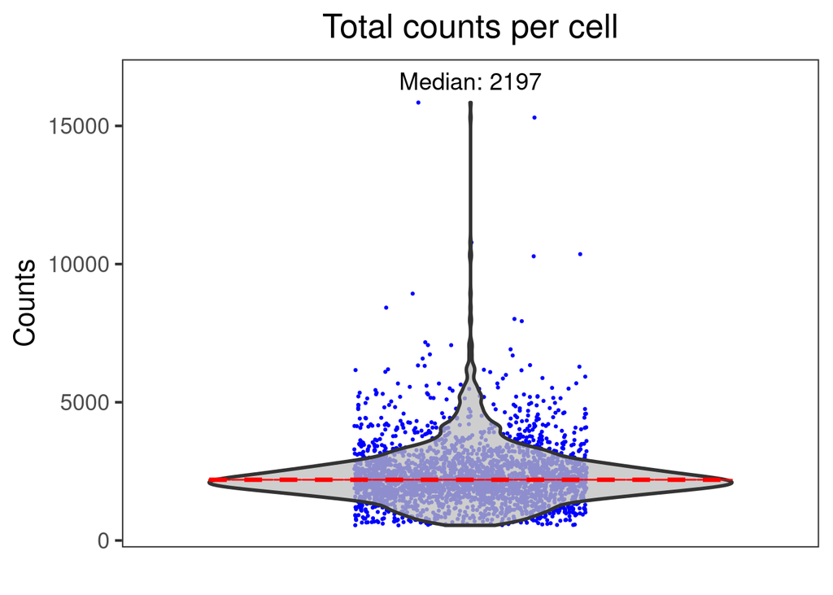

## 3.2 Total Features

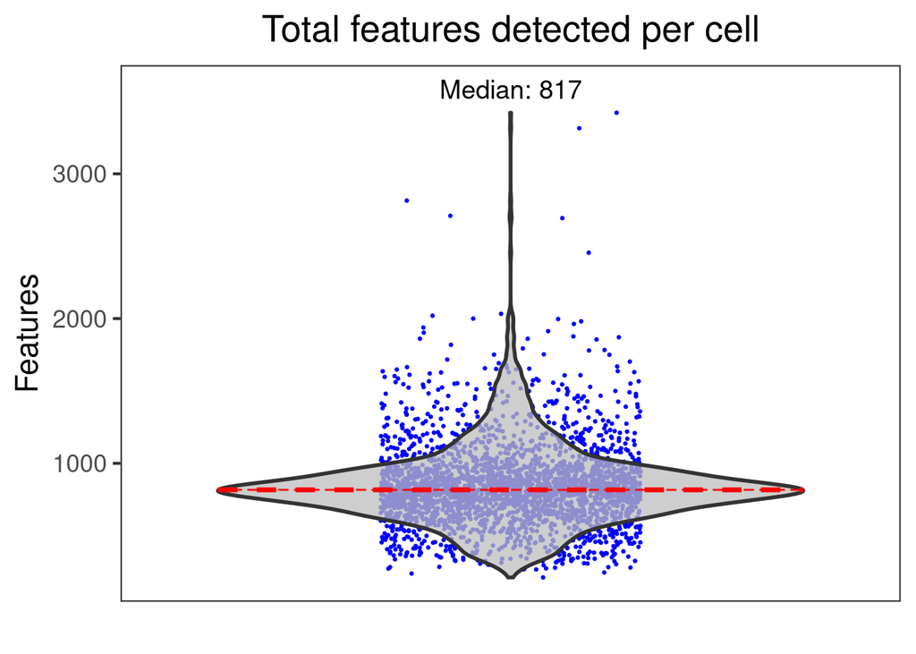

## 3.3 Percentage of Library Size Occupied by Top 50 Expressed Features

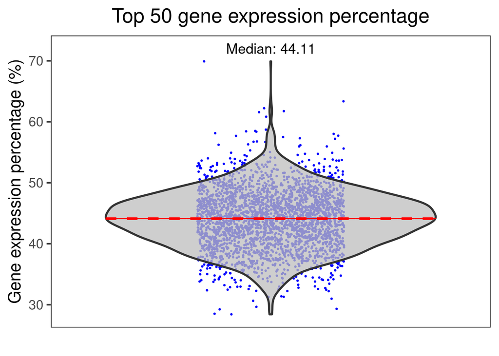

## 3.4 Total Mitochondrial Counts

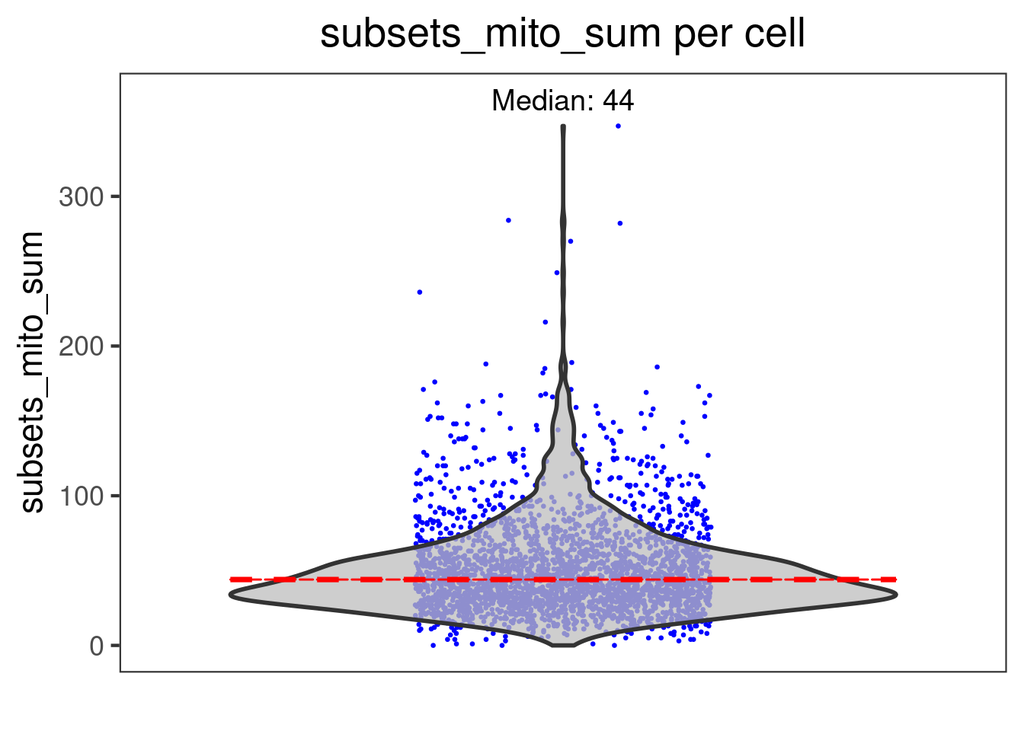

## 3.5 Total Mitochondrial Features

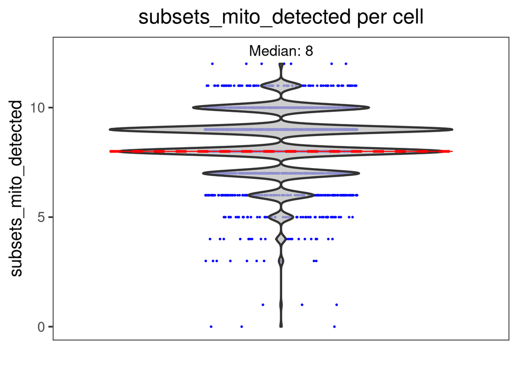

## 3.6 Percentage of Mitochondrial Counts

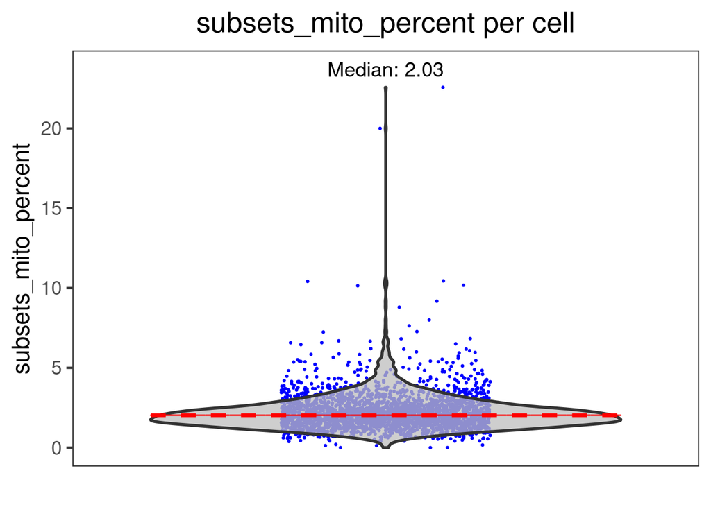

## 3.7 Parameters

| useAssay | counts |
| --- | --- |
| collectionName | mito |
| geneSetList | NULL |
| geneSetListLocation | rownames |
| percent_top | 50 100 200 500 |
| use_altexps | FALSE |
| flatten | TRUE |
| detectionLimit | 0 |
| packageVersion | 1.20.1 |

In this function, the `inSCE` parameter is the input SingleCellExperiment object, while the `useAssay` parameter is the assay object that in the SingleCellExperiment object the user wishes to use.

# 4 Doublet Detection

## 4.1 ScDblFinder

[scDblFinder](https://bioconductor.org/packages/release/bioc/html/scDblFinder.html) is a doublet detection algorithm in the `scran` package. scDblFinder aims to detect doublets by creating a simulated doublet from existing cells and projecting it to the same PCA space as the cells. The wrapper function `runScDblFinder` can be used to separately run the scDblFinder algorithm on its own. The wrapper function `plotScDblFinderResults` can be used to plot the QC outputs from the scDblFinder algorithm. The output of scDblFinder is a `scDblFinder_doublet_score` and `scDblFinder_doublet_call`. The doublet score of a droplet will be higher if the it is deemed likely to be a doublet.

### 4.1.1 pbmc3k

#### 4.1.1.1 ScDblFinder Doublet Score

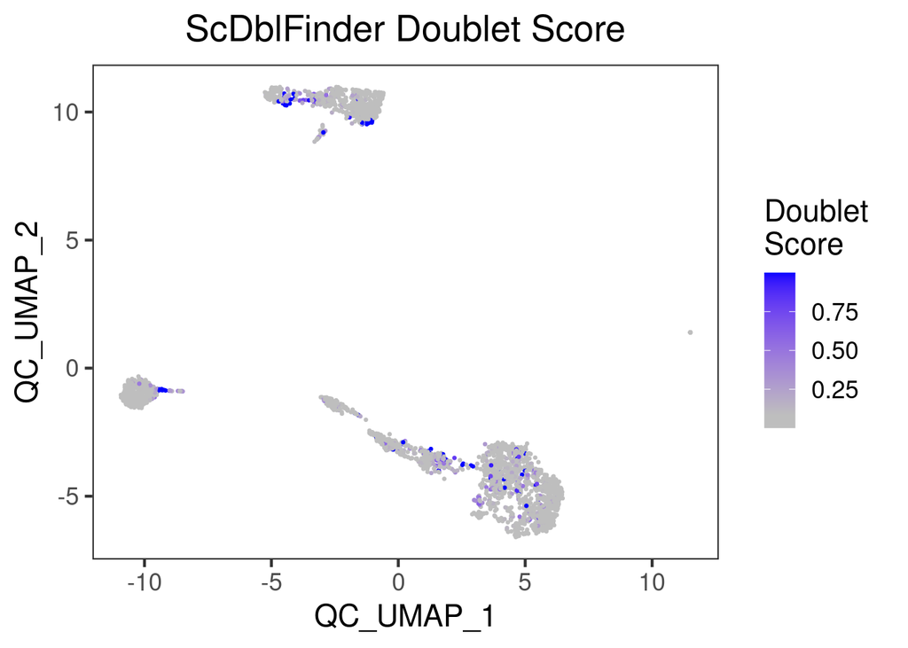

#### 4.1.1.2 Density Score

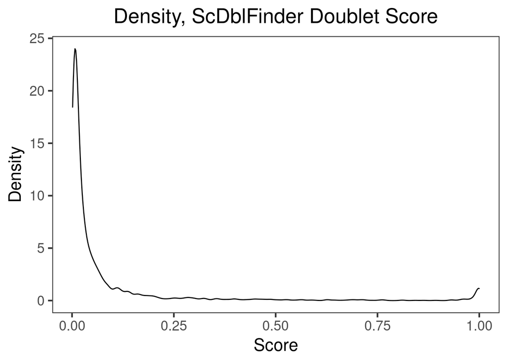

#### 4.1.1.3 Violin Score

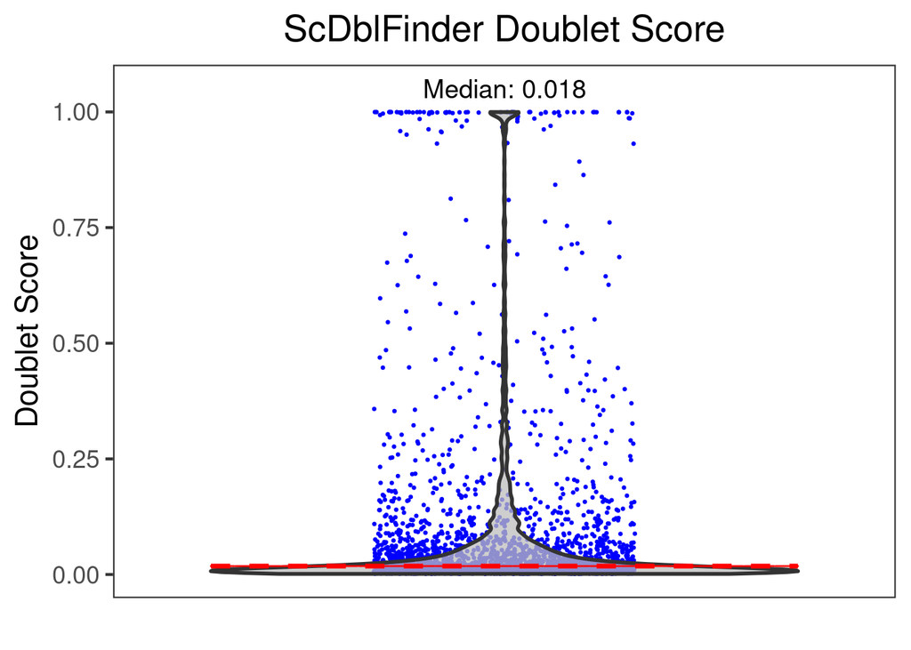

#### 4.1.1.4 Parameters

| useAssay | counts |
| --- | --- |
| nNeighbors | 50 |
| simDoublets | 10000 |
| seed | 12345 |
| packageVersion | 1.6.0 |

The `nNeighbors` parameter is the number of nearest neighbor used to calculate the density for doublet detection. `simDoublets` is used to determine the number of simulated doublets used for doublet detection.

# 5 Ambient RNA Detection

## 5.1 DecontX

In droplet-based single cell technologies, ambient RNA that may have been released from apoptotic or damaged cells may get incorporated into another droplet, and can lead to contamination. [decontX](https://rdrr.io/bioc/celda/man/decontX.html), available from the [celda](https://bioconductor.org/packages/release/bioc/html/celda.html), is a Bayesian method for the identification of the contamination level at a cellular level. The wrapper function `runDecontX` can be used to separately run the DecontX algorithm on its own. The wrapper function `plotDecontXResults` can be used to plot the QC outputs from the DecontX algorithm. The outputs of `runDecontX` are `decontX_contamination` and `decontX_clusters`. `decontX_contamination` is a numeric vector which characterizes the level of contamination in each cell. Clustering is performed as part of the `runDecontX` algorithm. `decontX_clusters` is the resulting cluster assignment, which can also be labeled on the plot.

### 5.1.1 pbmc3k

#### 5.1.1.1 DecontX Contamination Score

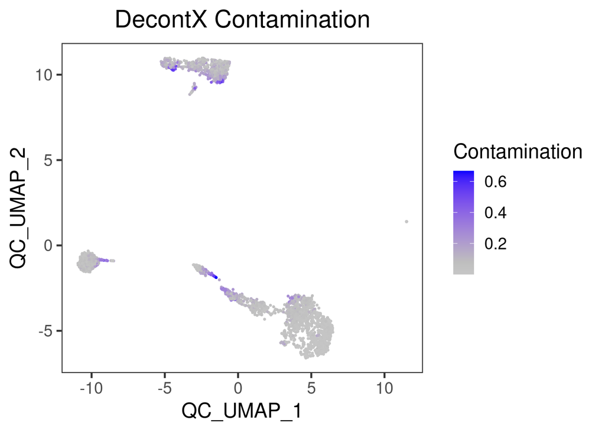

#### 5.1.1.2 Density Score

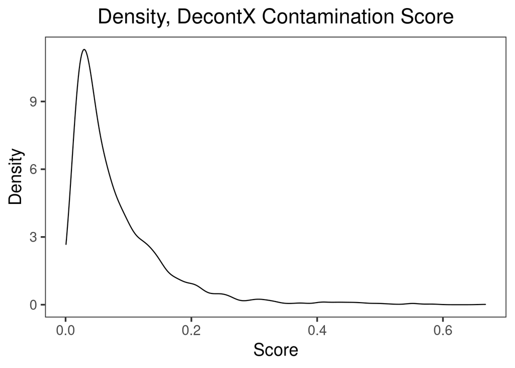

#### 5.1.1.3 Violin Score

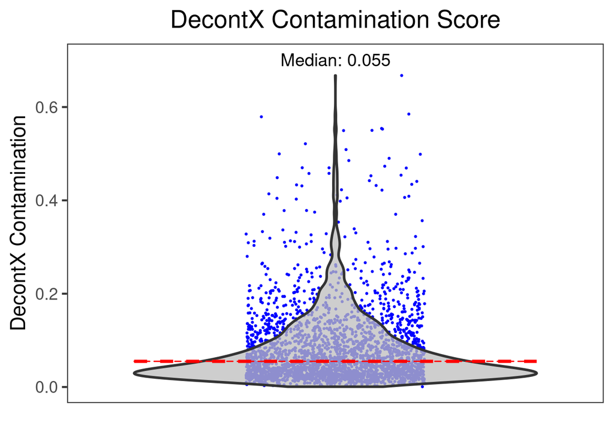

#### 5.1.1.4 DecontX Clusters

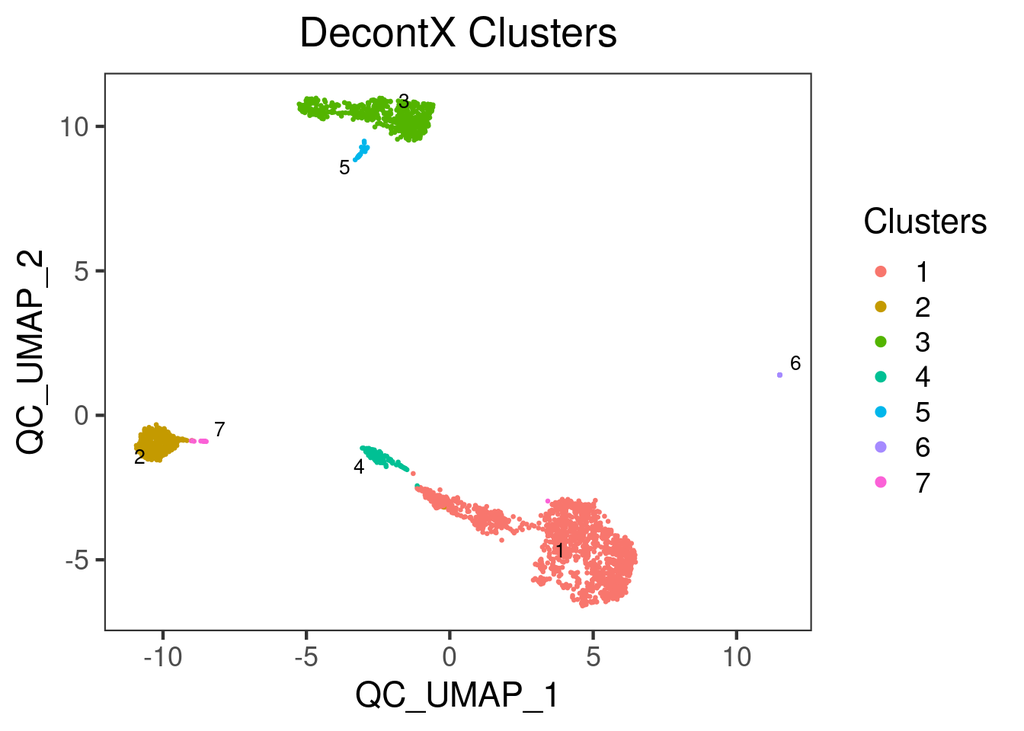

#### 5.1.1.5 Parameters

| useAssay | counts |
| --- | --- |
| z | NULL |
| maxIter | 500 |
| delta | 10 10 |
| estimateDelta | TRUE |
| convergence | 0.001 |
| iterLogLik | 10 |
| varGenes | 5000 |
| dbscanEps | 1 |
| seed | 12345 |
| logfile | NULL |
| verbose | TRUE |
| packageVersion | 1.8.1 |

# 6 Session Information